# scLASER Longitudinal Pipeline: 2 Time Points then 3 Time Points

fanzhang labs [Lab Website - https://fanzhanglab.org](https://fanzhanglab.org) [Lab GitHub - https://github.com/fanzhanglab](https://github.com/fanzhanglab)

2025-12-15

```r
library(scLASER)
library(dplyr)
library(ggplot2)
```

```r
# Helper: pick the NAM PC with the smallest LRT p-value and plot it on UMAP
plot_top_nam_pc_umap <- function(object,
                                 p_col_candidates   = c("lrt_pval", "lrt_p", "p.value", "pval"),
                                 nam_col_candidates = c("NAMscore", "nam_pc", "pc", "NAM_PC", "score"),
                                 umap_col_candidates = list(
                                   x = c("UMAP1", "umap_1", "UMAP_1", "Dim1"),
                                   y = c("UMAP2", "umap_2", "UMAP_2", "Dim2")
                                 ),
                                 zscore = TRUE,
                                 facet_by = "disease",
                                 label_cell_types = TRUE,
                                 cell_type_col = "cell_type",
                                 label_size = 3) {

  stopifnot(inherits(object, "scLASER"))

  if (is.null(object@pipeline_output) || nrow(object@pipeline_output) == 0) {
    stop("object@pipeline_output is empty. Run longAnalyses_plusModelSelection() first.")
  }
  if (is.null(object@umap) || nrow(object@umap) == 0) {
    stop("object@umap is empty. Run compute_umap() first.")
  }
  if (is.null(object@nam_pcs) || nrow(object@nam_pcs) == 0) {
    stop("object@nam_pcs is empty. Run association_nam_scLASER() first.")
  }

  # Require row alignment across slots
  n_md  <- nrow(object@metadata)
  n_um  <- nrow(object@umap)
  n_nam <- nrow(object@nam_pcs)
  if (!(n_md == n_um && n_md == n_nam)) {
    stop(
      "Row mismatch across slots:\n",
      "  nrow(metadata) = ", n_md, "\n",
      "  nrow(umap)     = ", n_um, "\n",
      "  nrow(nam_pcs)  = ", n_nam, "\n",
      "These must match if you want to cbind() them."
    )
  }

  po <- object@pipeline_output

  # Find p-value column
  p_col <- p_col_candidates[p_col_candidates %in% colnames(po)][1]
  if (is.na(p_col)) {
    stop("Could not find an LRT p-value column in pipeline_output. Tried: ",
         paste(p_col_candidates, collapse = ", "))
  }

  # Find NAM PC identifier column
  nam_col <- nam_col_candidates[nam_col_candidates %in% colnames(po)][1]
  if (is.na(nam_col)) {
    stop("Could not find a NAM PC identifier column in pipeline_output. Tried: ",
         paste(nam_col_candidates, collapse = ", "))
  }

  po[[p_col]] <- as.numeric(po[[p_col]])
  po <- po[is.finite(po[[p_col]]), , drop = FALSE]
  if (nrow(po) == 0) stop("No finite p-values in pipeline_output.")

  top_row <- po[which.min(po[[p_col]]), , drop = FALSE]
  top_pc  <- as.character(top_row[[nam_col]])

  if (!top_pc %in% colnames(object@nam_pcs)) {
    stop("Top NAM PC '", top_pc, "' not found in colnames(object@nam_pcs).")
  }

  # UMAP coordinate columns
  um <- object@umap
  um1 <- umap_col_candidates$x[umap_col_candidates$x %in% colnames(um)][1]
  um2 <- umap_col_candidates$y[umap_col_candidates$y %in% colnames(um)][1]
  if (is.na(um1) || is.na(um2)) {
    stop("Could not find UMAP coordinate columns in object@umap.")
  }

  # Build plotting DF by row alignment
  plot_df <- cbind(object@metadata, object@umap)
  plot_df$nam_score <- as.numeric(object@nam_pcs[, top_pc])

  if (zscore) {
    plot_df$nam_score <- as.numeric(scale(plot_df$nam_score))
  }

  p <- ggplot2::ggplot(
    plot_df,
    ggplot2::aes(x = .data[[um1]], y = .data[[um2]], color = nam_score)
  ) +
    ggplot2::geom_point(size = 0.6, alpha = 0.85) +
    ggplot2::scale_color_gradient2(
      low = "#2C7BB6",   # blue
      mid = "white",
      high = "#D7191C",  # red
      midpoint = 0
    ) +
    ggplot2::labs(
      title = paste0("Top NAM PC on UMAP: ", top_pc),
      subtitle = paste0("min LRT p = ", signif(top_row[[p_col]], 3)),
      x = "UMAP1",
      y = "UMAP2",
      color = if (zscore) paste0(top_pc, " (z)") else top_pc
    ) +
    ggplot2::theme_classic()

  # Facet (optional)
  if (!is.null(facet_by) && facet_by %in% colnames(plot_df)) {
    p <- p + ggplot2::facet_wrap(stats::as.formula(paste("~", facet_by)), nrow = 1)
  }

  # Add one label per cell type at median UMAP position
  if (isTRUE(label_cell_types)) {
    if (!cell_type_col %in% colnames(plot_df)) {
      stop("cell_type_col '", cell_type_col, "' not found in metadata/plot_df.")
    }

    label_df <- plot_df %>%
      dplyr::group_by(.data[[cell_type_col]]) %>%
      dplyr::summarise(
        .x = stats::median(.data[[um1]], na.rm = TRUE),
        .y = stats::median(.data[[um2]], na.rm = TRUE),
        .groups = "drop"
      ) %>%
      dplyr::rename(label = !!cell_type_col)

    p <- p +
      ggplot2::geom_text(
        data = label_df,
        ggplot2::aes(x = .x, y = .y, label = label),
        inherit.aes = FALSE,
        size = label_size
      )
  }

  p
}
```

# 1 Part A — Pipeline with **2 Time Points** (V0, V1)

## 1.1 A1. Simulate 2TP data

```r
cell_types  <- LETTERS[1:(5 + 2)]  # A-G (5 major + 2 minor)
time_points <- 2                   # V0, V1

E_prog <- matrix(
  0, nrow = length(cell_types), ncol = time_points,
  dimnames = list(cell_types, paste0("V", 0:(time_points - 1)))
)

E_ctrl <- matrix(
  0, nrow = length(cell_types), ncol = time_points,
  dimnames = list(cell_types, paste0("V", 0:(time_points - 1)))
)

# Interacting cell types in this setup:
# majors: first 2 => A, B
# minors: last 1  => G
# (so A, B, G are the interacting ones)
E_prog["A", ] <- c(+0.20, -0.20)
E_prog["B", ] <- c(-0.20, -0.05)  # opposite direction vs A
E_prog["G", ] <- c(+0.20, -0.20)

# Controls remain stable (all zeros) via E_ctrl

d2 <- generate_dummy_data(
  n_cells = 800,
  sd_celltypes = 0.15,
  n_major_cell_types = 5,
  n_minor_cell_types = 2,
  relative_abundance = 0.25,
  n_major_interact_celltypes = 2,
  n_minor_interact_celltypes = 1,
  n_individuals = 20,
  n_batchs = 3,

  interaction_feature = "visit",
  time_points = 2,
  test_var = "disease",
  prop_disease = 0.5,

  fc_interact = 0.20,               # ignored when effect matrices provided
  interaction_type = "specific",    # ignored when effect matrices provided
  seed = 2025,

  effect_mat_progressor = E_prog,
  effect_mat_control    = E_ctrl
)
dplyr::glimpse(d2)
```

```
#> Rows: 174,313
#> Columns: 11
#> $ sample_id     <chr> "SUB_20_V1", "SUB_13_V1", "SUB_7_V1", "SUB_7_V1", "SUB_1~
#> $ cell_type     <chr> "C", "C", "B", "D", "D", "E", "A", "C", "D", "B", "B", "~
#> $ subject_id    <chr> "SUB_20", "SUB_13", "SUB_7", "SUB_7", "SUB_13", "SUB_4",~
#> $ visit         <int> 1, 1, 1, 1, 0, 0, 0, 0, 0, 1, 1, 1, 1, 0, 1, 1, 0, 1, 1,~
#> $ sex           <int> 0, 0, 1, 1, 0, 1, 1, 0, 1, 1, 1, 1, 0, 1, 0, 0, 1, 1, 0,~
#> $ disease       <int> 1, 0, 0, 0, 0, 1, 0, 0, 1, 0, 0, 0, 0, 1, 0, 1, 1, 0, 0,~
#> $ age           <int> 21, 39, 43, 43, 39, 21, 32, 58, 34, 43, 32, 37, 55, 34, ~
#> $ bmi           <int> 16, 20, 25, 25, 20, 29, 31, 29, 26, 25, 31, 30, 22, 17, ~
#> $ batch         <fct> 2, 1, 1, 1, 1, 1, 1, 1, 1, 1, 1, 3, 1, 3, 2, 2, 3, 3, 1,~
#> $ interaction   <chr> "visit:disease", "visit:disease", "visit:disease", "visi~
#> $ interact_term <int> 1, 0, 0, 0, 0, 0, 0, 0, 0, 0, 0, 0, 0, 0, 0, 1, 0, 0, 0,~
```

## 1.2 A2. Generate pseudo-PCs (2TP)

```r
pcs2 <-  generate_pseudo_pcs_time(
  d2,
  n_pcs = 20,
  cluster_pcs = 1:20,
  disease_pcs = 0,
  sex_pcs = 0,
  age_pcs = 0,
  bmi_pcs = 0,
  batch_pcs = 0,
  interaction_pcs = 0,
  visit_pcs = 0,
  subject_pcs = 0,

  cluster_ratio = 0.8,
  disease_ratio = 0,
  sex_ratio = 0,
  age_ratio = 0,
  bmi_ratio = 0,
  batch_ratio = 0,
  interaction_ratio = 0,
  visit_ratio = 0,
  subject_ratio = 0,

  scale_factor = 5,
  cluster_col = "cell_type",
  sex_col = "sex",
  age_col = "age",
  bmi_col = "bmi",
  batch_col = "batch",
  disease_col = "disease",
  visit_col = "visit",

  seed = 1234
)
dim(pcs2)
```

```
#> [1] 174313     20
```

## 1.3 A3. Create object, visualize proportions (2TP)

```r
obj2 <- scLASER(metadata = d2, pcs = pcs2)

obj2
```

```
#> scLASER object
#> ---------------
#> Slots:
#>   metadata:  174313 11
#>   pcs:  174313 20
#>   umap:
#>   harmony:
#>   nam_pcs:
#>   NAM_matrix:
#>   plsda_LV:
#>   pipeline_output:
```

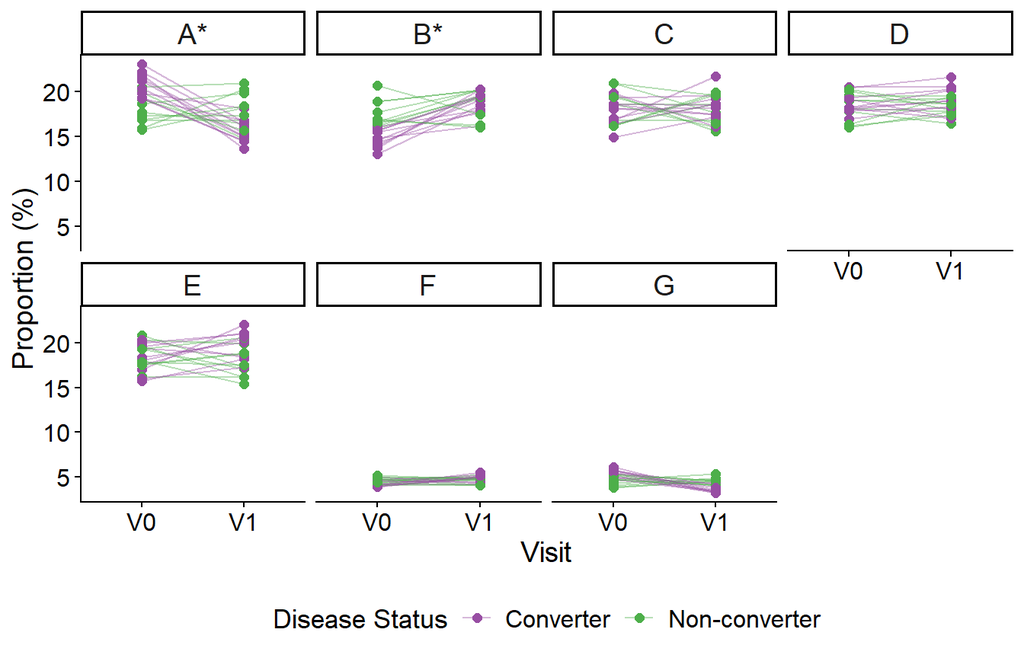

```r
plot_celltype_proportions(obj2)
```

### 1.3.1 What lives in a scLASER object (slots)

A `scLASER` object is an S4 container that stores each intermediate output of the pipeline in a dedicated **slot**, so later steps can reuse results without recomputing them. In this tutorial we populate the slots in the following order:

- `@metadata` — per-cell metadata (sample/subject IDs, visit, disease, covariates, etc.). Created by `generate_dummy_data()` and passed into `scLASER()`.
- `@pcs` — synthetic principal components used as the working low-dimensional space. Created by `generate_pseudo_pcs_time()` and stored when you call `scLASER(metadata=..., pcs=...)`.
- `@umap` — 2D UMAP embedding for visualization. Created by `compute_umap()`.
- `@harmony` — batch-corrected PC embedding. Created by `run_harmony()`.
- `@nam_pcs` — neighborhood abundance “PCs” (association score vectors). Created by `association_nam_scLASER()`.
- `@NAM_matrix` — neighborhood abundance matrix used to derive `@nam_pcs` (also created by `association_nam_scLASER()`).
- `@pipeline_output` — tidy results table from longitudinal model selection (including LRT p-values). Created by `longAnalyses_plusModelSelection()`.

## 1.4 A4. UMAP & Harmony (2TP)

```r
obj2 <- compute_umap(obj2, n_neighbors = 30, metric = "cosine", min_dist = 0.01)

obj2 <- run_harmony(
  obj2,
  batch_col = "sample_id",
  theta = 2,
  epsilon.cluster = -Inf,
  epsilon.harmony = -Inf,
  max.iter.cluster = 30,
  max.iter.harmony = 1,
  plot_convergence = FALSE
)
```

## 1.5 A5. Association & Longitudinal modeling (2TP)

The following 2 functions `association_nam_scLASER` and `longAnalyses_plusModelSelection` are the main protagonist of our pipeline. In the previous steps, the goal was to harmonize the pcs to remove any batch effect. In these steps we create the Neighborhood Abundance Matrix from those harmonized pcs. Further we determine which of those NAM PCs or Association score vectors are associated with the interaction of disease and visit.

```r
obj2@metadata$disease = as.numeric(obj2@metadata$disease)
obj2 <- association_nam_scLASER(
  obj = obj2,
  test_var = "disease",
  samplem_key = "sample_id",
  graph_use = "RNA_nn",
  batches = "batch",
  covs = c("age", "sex"),
  Nnull = 1000,
  local_test = TRUE,n_pcs = 20,
  seed = 1234, return_nam = T, key = "NAM_"
)

# Align names for longitudinal analysis + plotting
rownames(obj2@nam_pcs) <- obj2@metadata$sample_id

obj2 <- longAnalyses_plusModelSelection(
  obj2,
  disease_var = "disease",
  subject_var = "subject_id",
  sample_var  = "sample_id",
  time_var    = "visit",
  covariates  = c("age", "sex")
)

obj2@pipeline_output
```

```
#>     NAMscore         best_model    coefficient         Value    Std.Error
#> 1        PC1 time as continuous    (Intercept)  5.956541e-04 1.224875e-05
#> 2        PC1 time as continuous       disease1 -2.275836e-03 1.483841e-05
#> 3        PC1 time as continuous          visit -1.758920e-03 1.504299e-05
#> 4        PC1 time as continuous            age  7.144154e-06 1.347545e-07
#> 5        PC1 time as continuous            sex  5.701574e-04 1.127541e-05
#> 6        PC1 time as continuous disease1:visit  4.014025e-03 2.141087e-05
#> 7        PC2 time as continuous    (Intercept)  7.480945e-04 1.335471e-05
#> 8        PC2 time as continuous       disease1 -1.220039e-03 1.617817e-05
#> 9        PC2 time as continuous          visit  4.324155e-04 1.640127e-05
#> 10       PC2 time as continuous            age  5.367759e-07 1.469239e-07
#> 11       PC2 time as continuous            sex -3.447563e-04 1.229333e-05
#> 12       PC2 time as continuous disease1:visit  6.173578e-05 2.334410e-05
#> 13       PC3 time as continuous    (Intercept) -2.390515e-03 1.110301e-05
#> 14       PC3 time as continuous       disease1  2.018487e-03 1.345045e-05
```

[output cut: 348 more lines]

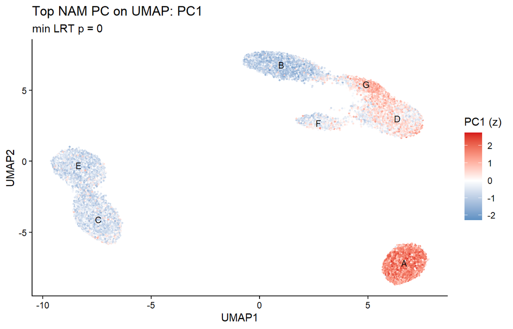

```r
plot_top_nam_pc_umap(obj2, facet_by = NULL)
```

# 2 Part B — Pipeline with **3 Time Points** (V0, V1, V2)

## 2.1 B1. Simulate 3TP data

```r
cell_types  <- LETTERS[1:(5 + 2)]  # A-G (5 major + 2 minor)
time_points <- 3                   # V0, V1, V2

E_prog <- matrix(
  0, nrow = length(cell_types), ncol = time_points,
  dimnames = list(cell_types, paste0("V", 0:(time_points - 1)))
)

E_ctrl <- matrix(
  0, nrow = length(cell_types), ncol = time_points,
  dimnames = list(cell_types, paste0("V", 0:(time_points - 1)))
)




E_prog["A", ] <- c(+0.20, -0.10, +0.10)
E_prog["B", ] <- c(-0.20, -0.10, -0.10)
E_prog["G", ] <- c(+0.20, -0.10, +0.10)


d3 <- generate_dummy_data(
  n_cells = 800,
  sd_celltypes = 0.15,
  n_major_cell_types = 5,
  n_minor_cell_types = 2,
  relative_abundance = 0.25,
  n_major_interact_celltypes = 2,
  n_minor_interact_celltypes = 1,
  n_individuals = 20,
  n_batchs = 3,

  interaction_feature = "visit",
  time_points = 3,
  test_var = "disease",
  prop_disease = 0.5,

  fc_interact = 0.20,               # ignored when effect matrices provided
  interaction_type = "specific",    # ignored when effect matrices provided
  seed = 2025,

  effect_mat_progressor = E_prog,
  effect_mat_control    = E_ctrl
)


dplyr::count(d3, visit)
```

```
#>   visit     n
#> 1     0 89494
#> 2     1 85215
#> 3     2 88641
```

## 2.2 B2. Generate pseudo-PCs (3TP)

```r
pcs3 <- generate_pseudo_pcs_time(
  d3,
  n_pcs = 20,
  cluster_pcs = 1:20,
  disease_pcs = 0,
  sex_pcs = 0,
  age_pcs = 0,
  bmi_pcs = 0,
  batch_pcs = 0,
  interaction_pcs = 0,
  visit_pcs = 0,
  subject_pcs = 0,

  cluster_ratio = 0.8,
  disease_ratio = 0,
  sex_ratio = 0,
  age_ratio = 0,
  bmi_ratio = 0,
  batch_ratio = 0,
  interaction_ratio = 0,
  visit_ratio = 0,
  subject_ratio = 0,

  scale_factor = 5,
  cluster_col = "cell_type",
  sex_col = "sex",
  age_col = "age",
  bmi_col = "bmi",
  batch_col = "batch",
  disease_col = "disease",
  visit_col = "visit",
  seed = 1234
)
dim(pcs3)
```

```
#> [1] 263350     20
```

## 2.3 B3. Create object, visualize proportions (3TP)

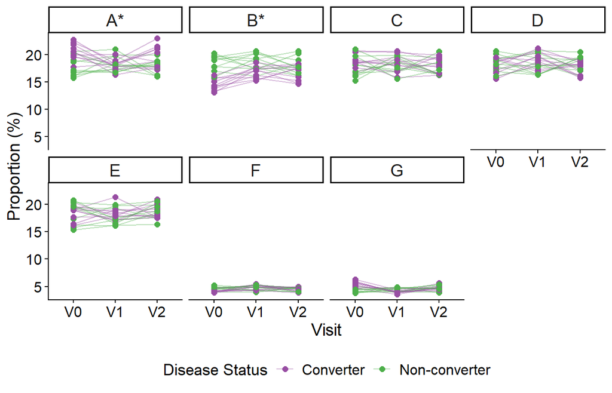

```r
obj3 <- scLASER(metadata = d3, pcs = pcs3)

plot_celltype_proportions(obj3)
```

```r
obj3
```

```
#> scLASER object
#> ---------------
#> Slots:
#>   metadata:  263350 11
#>   pcs:  263350 20
#>   umap:
#>   harmony:
#>   nam_pcs:
#>   NAM_matrix:
#>   plsda_LV:
#>   pipeline_output:
```

## 2.4 B4. UMAP & Harmony (3TP)

```r
obj3 <- compute_umap(obj3, n_neighbors = 30, metric = "cosine", min_dist = 0.01)

obj3 <- run_harmony(
  obj3,
  batch_col = "sample_id",
  theta = 2,
  epsilon.cluster = -Inf,
  epsilon.harmony = -Inf,
  max.iter.cluster = 30,
  max.iter.harmony = 1,
  plot_convergence = FALSE
)
```

## 2.5 B5. Association & Longitudinal modeling (3TP)

As same as the section A5 in this tutorial, the following 2 functions `association_nam_scLASER` and `longAnalyses_plusModelSelection` are the main protagonist of our pipeline used in this example. In the previous steps, the goal was to harmonize the pcs to remove any batch effect. In these steps we create the Neighborhood Abundance Matrix from those harmonized pcs. Further we determine which of those NAM PCs or Association score vectors are associated with the interaction of disease and visit.

```r
obj3@metadata$disease = as.numeric(obj3@metadata$disease)
obj3 <- association_nam_scLASER(
  obj = obj3,
  test_var = "disease",
  samplem_key = "sample_id",
  graph_use = "RNA_nn",
  batches = "batch",
  covs = c("age", "sex"),
  Nnull = 1000,
  local_test = TRUE,n_pcs = 20,
  seed = 1234, return_nam = T, key = "NAM_"
)

rownames(obj3@nam_pcs) <- obj3@metadata$sample_id

obj3 <- longAnalyses_plusModelSelection(
  obj3,
  disease_var = "disease",
  subject_var = "subject_id",
  sample_var  = "sample_id",
  time_var    = "visit",
  covariates  = c("age", "sex")
)

obj3@pipeline_output
```

```
#>     NAMscore          best_model              coefficient         Value
#> 1        PC1      quadratic time              (Intercept) -1.025865e-03
#> 2        PC1      quadratic time                 disease1 -1.560266e-03
#> 3        PC1      quadratic time                    visit -6.406451e-04
#> 4        PC1      quadratic time               I(visit^2)  5.603933e-04
#> 5        PC1      quadratic time                      age  7.888817e-06
#> 6        PC1      quadratic time                      sex  1.026545e-03
#> 7        PC1      quadratic time           disease1:visit  3.605284e-03
#> 8        PC1      quadratic time      disease1:I(visit^2) -1.755757e-03
#> 9        PC2      quadratic time              (Intercept)  4.219752e-05
#> 10       PC2      quadratic time                 disease1 -1.189930e-03
#> 11       PC2      quadratic time                    visit -1.274764e-03
#> 12       PC2      quadratic time               I(visit^2)  8.494978e-04
#> 13       PC2      quadratic time                      age -1.532961e-05
#> 14       PC2      quadratic time                      sex  2.706176e-04
```

[output cut: 468 more lines]

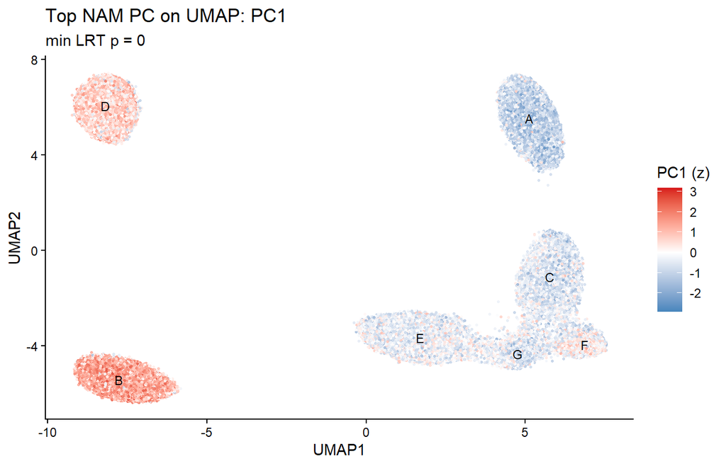

```r
plot_top_nam_pc_umap(obj3, facet_by = NULL)
```